# 📃 Phân tích doanh số bán máy tính sách tay trong năm 2024

- *về months thì không có một quy luật nào cả đa phần khác hàng sẽ mua máy tính vào bất kì một ngày nào trong năm vd có thể ngày sinh nhật , ngày lãnh lưỡng*
- *một điểm khá bất ngờ là về sự cân bằng của các Operating System , tưởng trừng như window sẽ là sản phẩm được ưa chuộng nhất , nhưng không phải sản lượng bán của window chỉ ngang bằng một sản phẩm khá ít ngưới biết đến là freedos Nhưng trên thực thì không phải như vậy bản chất Freedos chỉ là một mã nguồn mở được viết bởi một kỹ sư IT khi microsoft không hỗ trợ MSDOS cho cong ty anh ta nữa vì vậy việc FreeDos cao chỉ vì chiêu trò thương mại của các hãng máy tính , họ sẽ cài FreeDos mã nguồn mở để sau đó người sử dụng từ cài windows lậu hoặc người dùng tự có bản quyền windows vì vậy trên thực tế thì tất cả khách hàng đều quan và có xu hướng sử dụng windows*  
  🧠 *===>> : xu hướng khác hàng thích sử và trung thành với Operating System window*
- Khám phá mối quan hệ giữa biến định tính và biến định lượng

```python
data.head()
```

|  | Brand | Processor | RAM (GB) | Storage | GPU | Screen Size (inch) | Resolution | Battery Life (hours) | Weight (kg) | Operating System | Price ($) | LY price | months |
| --- | --- | --- | --- | --- | --- | --- | --- | --- | --- | --- | --- | --- | --- |
| 0 | Apple | AMD Ryzen 3 | 64 | 512GB SSD | Nvidia GTX 1650 | 17.3 | 2560x1440 | 8.9 | 1.42 | FreeDOS | 3997.07 | 3897.07 | October |
| 1 | Razer | AMD Ryzen 7 | 4 | 1TB SSD | Nvidia RTX 3080 | 14.0 | 1366x768 | 9.4 | 2.57 | Linux | 1355.78 | 1255.78 | December |
| 2 | Asus | Intel i5 | 32 | 2TB SSD | Nvidia RTX 3060 | 13.3 | 3840x2160 | 8.5 | 1.74 | FreeDOS | 2673.07 | 2573.07 | October |
| 3 | Lenovo | Intel i5 | 4 | 256GB SSD | Nvidia RTX 3080 | 13.3 | 1366x768 | 10.5 | 3.10 | Windows | 751.17 | 651.17 | August |
| 4 | Razer | Intel i3 | 4 | 256GB SSD | AMD Radeon RX 6600 | 16.0 | 3840x2160 | 5.7 | 3.38 | Linux | 2059.83 | 1959.83 | October |

[output not shown]

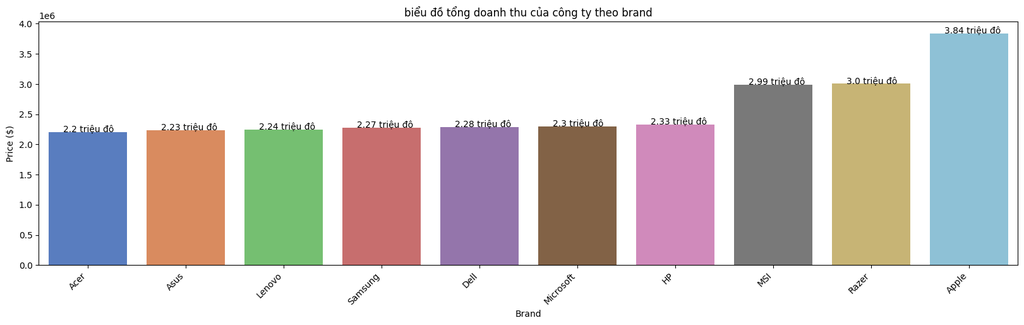

```python
# vẽ biểu đồ cột tổng doanh thu theo Brand
ve_bieu_do_cot_tong_doanh_thu("Brand","biểu đồ tổng doanh thu của công ty theo brand")
```

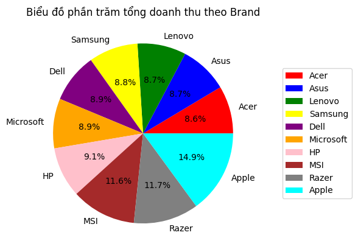

```python
# vẽ biểu đồ trong thể hiện phần trăm tổng doanh số theo Brand
ve_bieu_do_phan_tram_tong_doanh_so("Brand","Biểu đồ phần trăm tổng doanh thu theo Brand")
```

📊 Tổng doanh số bán máy tính theo Brand

- *Ta thấy rằng top 3 hãng mang lại doanh thu cao nhất lần lượt là Apple , razer , MSI , 3.84tr$ , 3tr$ và 2.99tr$ chiếm ~15% , 11.7% và 11.6% , mặc dù về sản lượng bán MSI chỉ đứng thứ 3 và razer thì đứng cuối cùng nhưng doanh số của razer mang lại cao thứ 2 chỉ sau Apple từ đấy ta có thể khẳng định được giả thuyết đã đưa ra ở trên về AMD đó là giá thành của AMD cao từ đó ta thấy được rằng lươn nhuận AMD mang lại cũng sẽ là cao*

[output not shown]

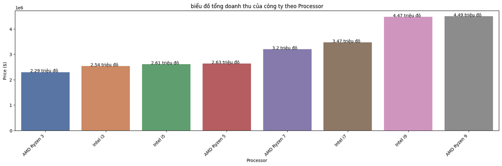

```python
# vẽ biểu đồ cột tổng doanh thu theo Processor
ve_bieu_do_cot_tong_doanh_thu("Processor","biểu đồ tổng doanh thu của công ty theo Processor")
```

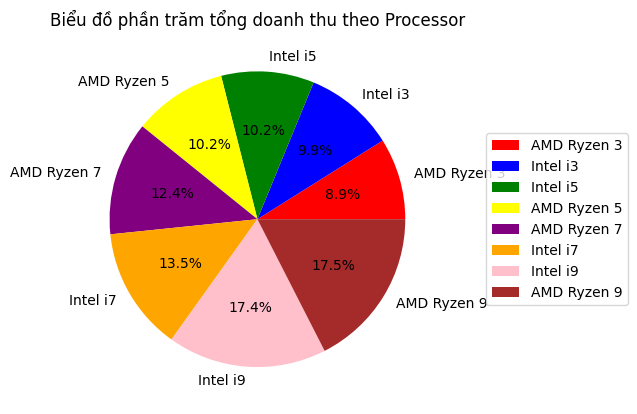

```python
# vẽ biểu đồ trong thể hiện phần trăm tổng doanh số theo Processor
ve_bieu_do_phan_tram_tong_doanh_so("Processor","Biểu đồ phần trăm tổng doanh thu theo Processor")
```

📊 Tổng doanh số bán máy tính theo Processer